# Norepinephrine reuptake inhibitors and risk of antihypertensive treatment intensification and major adverse cardiovascular events in patients with stable hypertension and depression - Desai - 2022 - P

- Skip to Article Content
- Skip to Article Information

**Working off-campus?** Learn about our remote access options

[Login / Register](https://accpjournals.onlinelibrary.wiley.com/action/showLogin?uri=%2Fdoi%2F10.1002%2Fphar.2686&aria-label=Log+in+or+Register)

[Pharmacotherapy: The Journal of Human Pharmacology and Drug Therapy](https://accpjournals.onlinelibrary.wiley.com/journal/18759114)

[Volume 42, Issue 6](https://accpjournals.onlinelibrary.wiley.com/toc/18759114/2022/42/6) p. 472-482

[figure not shown]

ORIGINAL RESEARCH ARTICLE

Full Access

# Norepinephrine reuptake inhibitors and risk of antihypertensive treatment intensification and major adverse cardiovascular events in patients with stable hypertension and depression

[Raj Desai](https://accpjournals.onlinelibrary.wiley.com/action/doSearch?ContribAuthorRaw=Desai%2C+Raj),

[Haesuk Park](https://accpjournals.onlinelibrary.wiley.com/action/doSearch?ContribAuthorRaw=Park%2C+Haesuk),

[Joshua D. Brown](https://accpjournals.onlinelibrary.wiley.com/action/doSearch?ContribAuthorRaw=Brown%2C+Joshua+D),

[Rajesh Mohandas](https://accpjournals.onlinelibrary.wiley.com/action/doSearch?ContribAuthorRaw=Mohandas%2C+Rajesh),

[Steven M. Smith](https://accpjournals.onlinelibrary.wiley.com/action/doSearch?ContribAuthorRaw=Smith%2C+Steven+M),

First published: 28 April 2022

https://doi.org/10.1002/phar.2686

Citations: 1

Check for Full Text

## Abstract

### Study Objective

To compare the risk of antihypertensive treatment intensification (TI) and major adverse cardiovascular events (MACE) with the initiation of serotonin norepinephrine reuptake inhibitors compared to selective serotonin reuptake inhibitors (SSRIs) in patients with stable hypertension and depression.

### Design

Retrospective cohort study.

### Data Source

IBM MarketScan® commercial claims database and Medicare Supplemental claims database from 2007 to 2019.

### Patients

Patients aged 18 years or older with stable treated hypertension and depression who newly initiate either serotonin norepinephrine reuptake inhibitors or SSRIs.

### Intervention

Serotonin norepinephrine reuptake inhibitors versus SSRIs.

### Conclusions

Among patients with stable hypertension and depression, initiation of serotonin norepinephrine reuptake inhibitors had a similar risk of antihypertensive TI and MACE compared to initiation of SSRIs. Future study with a larger sample size is needed to confirm our findings.

## 1 INTRODUCTION

Depression, a common psychiatric condition, occurs in more than 26% of patients with hypertension.<sup>1</sup> Antidepressants are widely prescribed for treatment of depression, yet their effects on comorbid disease states, including hypertension, are not well understood. Although antidepressants significantly reduce depressive symptoms, some antidepressants such as tricyclic antidepressants (TCAs) and serotonin norepinephrine reuptake inhibitors (SNRIs), particularly venlafaxine, have been significantly associated with increasing blood pressure (BP), thereby preventing BP control.<sup>2-4</sup> These antidepressants have been postulated to interfere with BP control by increasing levels of the neurotransmitter norepinephrine prompting central sympathetic nervous system activation, increasing cardiac output and BP.<sup>4</sup> However, most of the evidence of the BP-interfering effects of TCAs and SNRIs is limited to a few case reports and small case studies which often lacks generalizability and suffers from recall bias.<sup>5, 6</sup> In addition, only one randomized control trial evaluated the changes in BP with the use of venlafaxine (a SNRI) and imipramine (a TCA) compared to placebo in patients with depression.<sup>2</sup> Therefore, it remains unclear whether the use of these antidepressants is associated with clinically-relevant worsening of BP control in a real-world setting. In addition to their BP-interfering effects, several studies have suggested that the use of TCAs and SNRIs is associated with higher cardiovascular risk.<sup>7-9</sup> However, these studies suffer from several methodological limitations such as absence of an active comparator, residual confounding, and selection bias. Although uncontrolled BP often predicts increased cardiovascular morbidity and mortality,<sup>10-12</sup> data on the risk of major adverse cardiovascular events (MACE) due to the norepinephrine reuptake inhibition properties of SNRIs and TCAs in patients with stable hypertension do not exist.

Given the scarcity of data, we aimed to compare the risk of antihypertensive treatment intensification and MACE in patients who initiate antidepressants, stratified by their selectivity of neurotransmitter reuptake inhibition, i.e., SSRIs versus serotonin norepinephrine reuptake inhibitors in a cohort of patients with stable hypertension and depression. We hypothesized that patients initiating antidepressants with significant norepinephrine reuptake inhibition will have a higher risk for treatment intensification and cardiovascular events compared to those initiating selective serotonin reuptake inhibitors (i.e., SSRIs).

## 2 METHODOLOGY

### 2.1 Data sources

We conducted a retrospective cohort study using IBM MarketScan® commercial claims database and Medicare Supplemental claims database (January 2007 to December 2019). This database contains administrative claims data with de-identified information on enrollment, healthcare encounters and utilization, expenditures, and outpatient pharmacy records of more than 180 million employees and their dependents in United States covered by several health benefit plans. This database is generally considered representative of the US population receiving health insurance under employer-sponsored programs (≈49% of the US population).<sup>13</sup>

### 2.2 Study population

We identified adults (aged ≥18 years) with at least one prescription of antidepressants between January 1, 2008 and December 31, 2019. The 2007 data were used to allow for a minimum 12-month baseline period. We used a new-user design where patients entered the cohort when they newly initiated either an antidepressant which is an SSRI (i.e., antidepressants which preferentially inhibit serotonin transporters and that have little-to-no norepinephrine activity) or a serotonin norepinephrine reuptake inhibitor (i.e., antidepressants that inhibit serotonin and norepinephrine transporters), with the date of first fill defined as the index date. New initiation was defined as no use of any antidepressant in the 12-month washout period before first dispensing. Patients initiating both SSRIs and serotonin norepinephrine reuptake inhibitors on the index date were excluded. To ensure complete data were available to capture baseline information, patients were required to have ≥12 months of continuous medical and pharmacy enrollment before the index date (i.e., 12-month baseline period). A recorded diagnosis of depression (ICD-9-CM: 296.2x, 296.3x, 300.4x, 311.x, 309.0x, or 309.1x; ICD-10-CM: F32.x, F33.x, F34.1, or F43.21) in an outpatient or inpatient setting in the primary position was required during 12-month baseline period. Additionally, patients were required to meet the following definition of treated stable hypertension: (1) having an inpatient or outpatient diagnosis of hypertension (ICD-9-CM: 401.x; ICD-10-CM: I10.x) in the 12-month baseline period; (2) no recent modification of current antihypertensive regimen, defined as no addition or discontinuation of antihypertensive therapy or change in dose for at least 60 days prior to the index date. Patient were excluded if they had prior occurrence of the outcome (stroke or acute myocardial infarction [AMI]), or medication that interferes with BP control (i.e., oral hormonal contraceptives, nonsteroidal anti-inflammatory drugs, corticosteroids, or erythropoietin stimulating agents), or diagnosis of schizophrenia or bipolar disorder during the baseline period. Additionally, patients with at least one inpatient admission or two outpatient visits during the baseline period that had a diagnosis of fibromyalgia, neuropathic pain, attention deficit/hyperactivity disorder, obsessive compulsive disorder, and posttraumatic stress disorder in the primary position were excluded to ensure that study medications are likely used to treat depression. We did not exclude patients diagnosed with anxiety since almost half the patients with depression have an underlying anxiety disorder, and this risk might be even higher in patients with hypertension.<sup>14</sup> Finally, we excluded patients with a diagnosis of heart failure in the baseline period because many antihypertensives drugs are indicated in such patients even when BP is already well controlled (Table S1). Antidepressants dispensed on the index date were used to classify patients into mutually-exclusive groups: (1) SSRIs (fluoxetine, sertraline, paroxetine, citalopram, escitalopram, and fluvoxamine) or (2) serotonin norepinephrine reuptake inhibitors (venlafaxine, desvenlafaxine, duloxetine, milnacipran, levomilnacipran, imipramine, clorimipramine, amitriptyline, desipramine, protriptyline, trimipramine, amoxapine, and nortriptyline).<sup>15</sup> SSRIs were selected as an active comparator because they represent a comparable therapeutic alternative. We allowed gaps of up to 30 days between the end of the days of supply for one dispensing of antidepressants and the date of the next dispensing, i.e., a 30-day grace period.<sup>16</sup> Patients were allowed to switch between drugs in the same exposure group, provided any gap between exposure periods was within the aforementioned grace period.

### 2.3 Study covariates

During the 12-month baseline period including the index date, we assessed demographic characteristics (age, sex, region, calendar year of cohort entry), clinical comorbidities (anxiety, obesity, hyperlipidemia, valvular heart disease, atrial fibrillation, asthma, pneumonia, coronary heart disease, angina, chronic kidney disease/end stage renal disease),<sup>17</sup> prior medication use (statins, antiplatelet agents, proton pump inhibitors, anticonvulsants, antidiabetics, anticoagulants, nitrates, bisphosphates, benzodiazepines, opioids),<sup>18</sup> healthcare resource utilization patterns (number of inpatient hospitalizations, number of outpatient visits, and number of distinct prescription medications), and number of unique antihypertensive medications. Additionally, to better account for potential confounding by other comorbidities, we used the Quan-Charlson comorbidity index (calculated based on the presence of ICD-9-CM and ICD-10-CM diagnosis codes) incorporating 17 comorbidities.<sup>19</sup> Comorbidities were identified by requiring at least one diagnosis (ICD-9-CM or ICD-10-CM), in any position, in any setting. Prior medication use was identified in the baseline period using the national drug code from the outpatient dispensing claims.

### 2.4 Study outcomes

We evaluated two primary outcomes of interest: (1) antihypertensive treatment intensification; and (2) MACE. Antihypertensive treatment intensification was defined as either adding a new antihypertensive to the current regimen (i.e., augmentation), or increasing the daily dose (i.e., dose escalation) of an existing antihypertensive medication, after the initiation of antidepressants (i.e., index date of cohort entry).<sup>20</sup> For augmentation, at least 28 days of overlapping use of the added antihypertensive with the current antihypertensive was required to distinguish augmentation from antihypertensive switches. For dose escalation, an increase in total daily dose ≥50% compared to prior dose was required.<sup>21</sup> Loop diuretics were excluded for the outcome definition since these drugs are typically prescribed for different indications. The date when the antihypertensive regimen was intensified (augmentation or dose escalation) was considered the date of the outcome. Discontinuation of the current antihypertensive after the index date of cohort entry in favor of an alternative antihypertensive (i.e., switching) was not considered treatment intensification. Secondary outcomes included individual components of antihypertensive treatment intensification: augmentation only and dose escalation only. In the absence of BP measurements, the addition of new antihypertensive medications or dose escalation of existing medications, i.e., antihypertensive treatment intensification, is considered a reasonable approach to determine presence of uncontrolled BP.<sup>20</sup>

MACE was a composite outcome defined as first occurrence of ischemic or hemorrhagic stroke (ICD-9-CM: 430.xx, 431.xx, 433.x1, 434.xx [excluding 434.x0], 436.xx or ICD-10-CM: I60.xx, I61.x, I63.xxx) in the primary diagnosis position of any inpatient hospital discharge claims, or AMI (ICD-9-CM: 410.x or ICD-10-CM: I21.0-I21.4, I22.x) in the primary or secondary position of any inpatient hospital discharge claims. The date of first occurrence of hospitalization for stroke or AMI was defined as the date of the outcome. The claims-based algorithms to identify individual stroke and AMI outcomes have been validated previously and have a positive predictive value >90%.<sup>22, 23</sup> Secondary outcomes included individual components of MACE: AMI and stroke.

Our analysis was an “as-treated” approach, where, separately for each outcome, follow-up began on the index date and continue until earliest of the following: the occurrence of the outcome, end of medical or pharmacy benefits enrollment, study of drug discontinuation (defined as no evidence of refill within the 30 day grace period), switching to comparator drug, having a dispensing of medications that interference with BP control (as defined previously), or end of study period (December 31, 2019). The discontinuation date was defined as the end of days' supply of last prescription plus 30 days.

### 2.5 Statistical analysis

We conducted descriptive analyses by reporting means for continuous variables and frequencies and percentages for categorical variables and compared baseline characteristics among the two exposure groups (i.e., SSRIs vs. serotonin norepinephrine reuptake inhibitors). To control for potential confounding, we used 1:1 propensity score (PS) matching based on all the baseline covariates using a multivariable logistic regression model predicting the probability of receiving SSRIs versus serotonin norepinephrine reuptake inhibitors controlling for all measured baseline covariates. After matching, the balance in baseline covariates was assessed with absolute standardized mean difference, where differences less than. 0.1 were considered balanced.<sup>24</sup> Kaplan–Meier curves were generated to visualize the risk of the outcomes and log-rank test was used to compare the significance in the survival distribution of the two exposure groups. Cox proportional hazards models were used to estimate the adjusted hazard ratios (aHR) and 95% confidence interval (CI) for each outcome among serotonin norepinephrine reuptake inhibitor users compared with SSRIs users (reference). The proportional hazards assumption was tested using Schoenfeld residuals. We used SAS 9.4 (SAS Institute Inc., Cary, NC, USA) for data analyses and management. A *p* value less than 0.05 was considered statistically significant.

### 2.6 Sensitivity and subgroup analysis

To evaluate robustness of results, we conducted several sensitivity and subgroup analyses. First, we varied the definition of treated stable hypertension as having a diagnosis of hypertension with no modification of antihypertensive regimen for ≥90 days. Second, to avoid informative censoring, we used an “intention-to-treat” (ITT) approach where patients were followed from the index date irrespective of treatment changes (i.e., ignoring switching or discontinuation of study drugs). Third, we replicated the primary analysis using stabilized inverse probability of treatment weighting (SIPTW), rather than PS matching, for confounder adjustment. Fourth, we examined the association between individual serotonin norepinephrine reuptake inhibitors (venlafaxine, duloxetine, and nortriptyline) compared with fluoxetine (reference). For this analysis, to control for potential confounding, we re-estimated SIPTW based on propensity score. To assess heterogeneity of treatment effect, we stratified the analysis by age (18 to 64 years vs. ≥65 years) and sex (male vs. female) to test for differences in the risk of antihypertensive treatment intensification and MACE. To test the potential for effect modification, we included an interaction term of exposure and each subgroup in the Cox model. A p<sub>interaction</sub> value <0.05 was used to denote a significant difference among groups.

## 3 RESULTS

### 3.1 Cohort characteristics

The final study population after 1:1 PS matching included 19,160 patients (mean age: 52 years, 62% women), of which 9580 initiated serotonin norepinephrine reuptake inhibitors and 9580 initiated SSRIs (Figure 1). Table 1 shows baseline characteristics of patients before and after PS matching. Before PS matching, the exposure groups differed with respect to baseline characteristics, including use of benzodiazepine, anticonvulsants, opioids, and utilization of unique prescriptions and number of outpatient visits, as evidenced by standardized mean differences >0.1. After PS matching, the baseline characteristics were well balanced between the two exposure groups, with absolute standardized mean differences ≤0.1 for all measured covariates. In the SSRI group, the majority of the patients initiated citalopram (27.3%) followed by sertraline (25.7%) on the cohort entry date. In the serotonin norepinephrine reuptake inhibitor group, the majority of the patients initiated duloxetine (36.2%) followed by venlafaxine (32.7%) on the cohort entry date. The median follow-up time on treatment was approximately 7.5 months and 8.5 months for serotonin norepinephrine reuptake inhibitor group and SSRI group, respectively.

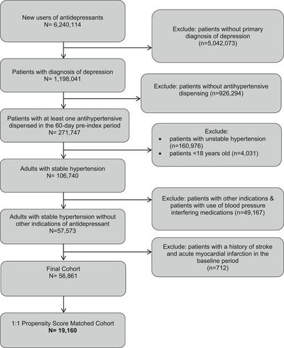

**FIGURE 1**

Open in figure viewer[PowerPoint](https://accpjournals.onlinelibrary.wiley.com/action/downloadFigures?id=phar2686-fig-0001&doi=10.1002%2Fphar.2686)

Cohort development flowchart

TABLE 1. Baseline characteristics of patients with stable hypertension initiating serotonin norepinephrine reuptake inhibitors versus selective serotonin reuptake inhibitors (SSRIs)

| Variables | Before PS matching Serotonin norepinephrine reuptake inhibitors | Before PS matching SSRIs | Before PS matching SMD | After PS matching Serotonin norepinephrine reuptake inhibitors | After PS matching SSRIs | After PS matching SMD |
| --- | --- | --- | --- | --- | --- | --- |
| *n* | 9587 | 47,274 |  | 9580 | 9580 |  |
| *Demographic characteristics* |  |  |  |  |  |  |
| Age | 52.3 ± 12.8 | 53.3 ± 14.8 | 0.07 | 52.3 ± 12.8 | 52.2 ± 14.4 | 0.01 |
| Female | 5952 (62.1) | 27,757 (58.7) |  | 5948 (62.1) | 5924 (61.8) | 0.01 |
| Region |  |  |  |  |  |  |
| Northeast | 1524 (15.9) | 8003 (16.9) | 0.1 | 1523 (15.9) | 1567 (16.4) | 0.03 |
| North central | 2375 (24.8) | 12,880 (27.2) |  | 2371 (24.7) | 2337 (24.4) |  |
| South | 3869 (40.4) | 16,658 (35.2) |  | 3867 (40.4) | 3900 (40.7) |  |
| West | 1726 (18.0) | 9333 (19.7) |  | 1726 (18.0) | 1683 (17.6) |  |
| Unknown | 93 (1.0) | 400 (0.8) |  | 93 (1.0) | 93 (1.0) |  |
| *History of comorbidities* |  |  |  |  |  |  |
| Chronic kidney disease | 128 (1.3) | 698 (1.5) | 0.01 | 127 (1.3) | 109 (1.1) | 0.02 |
| Obesity | 1245 (13.0) | 5839 (12.4) | 0.02 | 1244 (13.0) | 1253 (13.1) | 0 |
| Hyperlipidemia | 3726 (38.9) | 18,472 (39.1) | 0 | 3725 (38.9) | 3748 (39.1) | 0 |
| Atrial fibrillation | 253 (2.6) | 1655 (3.5) | 0.05 | 253 (2.6) | 259 (2.7) | 0 |
| Asthma | 678 (7.1) | 2904 (6.1) | 0.04 | 678 (7.1) | 675 (7.0) | 0 |
| Pneumonia | 174 (1.8) | 927 (2.0) | 0.01 | 174 (1.8) | 161 (1.7) | 0.01 |
| Angina | 207 (2.2) | 1084 (2.3) | 0.01 | 207 (2.2) | 223 (2.3) | 0.01 |
| CAD | 794 (8.3) | 4303 (9.1) | 0.03 | 793 (8.3) | 773 (8.1) | 0.01 |
| Anxiety | 2408 (25.1) | 10,922 (23.1) | 0.05 | 2404 (25.1) | 2433 (25.4) | 0.01 |
| Charlson comorbidity index | 0.8 ± 1.4 | 0.7 ± 1.3 | 0.04 | 0.8 ± 1.4 | 0.8 ± 1.4 | 0.01 |
| *History of medications* |  |  |  |  |  |  |
| Statins | 3123 (32.6) | 16,271 (34.4) | 0.04 | 3121 (32.6) | 3142 (32.8) | 0 |
| Bisphosphates | 242 (2.5) | 1229 (2.6) | 0 | 242 (2.5) | 244 (2.5) | 0 |
| Benzodiazepines | 2776 (29.0) | 11,088 (23.5) | 0.13 | 2773 (28.9) | 2784 (29.1) | 0 |
| Anticonvulsants | 1333 (13.9) | 3271 (6.9) | 0.23 | 1328 (13.9) | 1330 (13.9) | 0 |
| Opioids | 3778 (39.4) | 15,540 (32.9) | 0.14 | 3774 (39.4) | 3707 (38.7) | 0.01 |
| Antiplatelets | 302 (3.2) | 1571 (3.3) | 0.01 | 301 (3.1) | 289 (3.0) | 0.01 |
| Proton pump inhibitors | 2134 (22.3) | 9246 (19.6) | 0.07 | 2133 (22.3) | 2090 (21.8) | 0.01 |
| Antidiabetics | 1525 (15.9) | 6873 (14.5) | 0.04 | 1522 (15.9) | 1527 (15.9) | 0 |
| Nitrates | 228 (2.4) | 1281 (2.7) | 0.02 | 228 (2.4) | 217 (2.3) | 0.01 |
| Anticoagulants | 246 (2.6) | 1371 (2.9) | 0.02 | 246 (2.6) | 252 (2.6) | 0 |
| *Healthcare utilization* |  |  |  |  |  |  |
| Number of unique prescriptions | 19.9 ± 13.5 | 17.0 ± 11.5 | 0.23 | 19.9 ± 13.4 | 19.7 ± 13.4 | 0.01 |
| Number of outpatient visits | 19.7 ± 17.3 | 16.2 ± 15.0 | 0.22 | 19.6 ± 16.7 | 19.5 ± 18.5 | 0.01 |
| Number of inpatient visits | 0.8 ± 3.4 | 0.7 ± 3.3 | 0.02 | 0.8 ± 3.4 | 0.8 ± 4.0 | 0.01 |
| Number of antihypertensive medications | 1.0 ± 0.3 | 1.0 ± 0.2 | 0.02 | 1.0 ± 0.2 | 1.0 ± 0.2 | 0.01 |

- *Note*: Data are mean ± standard deviation (SD) or *n* (%).
- Abbreviations: CAD, coronary artery disease; PS, propensity score; SD, standard deviation; SMD, standardized mean differences.

### 3.2 Risk of antihypertensive treatment intensification

For the primary as-treated analysis, the serotonin norepinephrine reuptake inhibitor group had 1675 antihypertensive treatment intensification events over 3103 person-years of follow-up (incidence rate, 539.8 per 1000 person-years), compared with 1774 events over 3424 person-years of follow-up in the SSRI group (incidence rate, 518.1 per 1000 person-years). The risk of antihypertensive treatment intensification did not differ among patients initiating serotonin norepinephrine reuptake inhibitors versus SSRIs (aHR: 1.01, [95% CI: 0.94, 1.08]) (Table 2). For patients intensifying their antihypertensive regimen, the median number of encounters prior to antihypertensive treatment intensification were 11 and 10 in the serotonin norepinephrine reuptake inhibitor group and SSRI group, respectively. Additionally, the median number of days to antihypertensive treatment intensification were 41 and 40 in the serotonin norepinephrine reuptake inhibitor group and SSRI group, respectively. Similar findings were observed for the individual components of antihypertensive treatment intensification, with no significant difference in risk of augmentation (aHR: 0.99, [95% CI: 0.92, 1.07]) or dose escalation (aHR: 1.09, [95% CI: 0.95, 1.24]). Kaplan–Meier plots comparing the cumulative incidence of antihypertensive treatment intensification and its individual components among patients initiating serotonin norepinephrine reuptake inhibitor versus SSRIs were consistent with these findings (Figure 2, panels A–C).

TABLE 2. Risk for major adverse cardiovascular events and antihypertensive treatment intensification among initiators of serotonin norepinephrine reuptake inhibitors and selective serotonin reuptake inhibitors (SSRIs) (N = 19,160)

| Outcomes | Serotonin norepinephrine reuptake inhibitors (*n* = 9580) | SSRIs (*n* = 9580) |
| --- | --- | --- |
| *Major adverse cardiovascular events* |  |  |
| Days of follow-up, mean | 147.2 | 162.8 |
| No. of events, n | 15 | 17 |
| Person-years | 3862 | 4274 |
| Incidence rate per 1000 person-years | 3.9 | 4 |
| Adjusted HR (95% CI) | 0.98 (0.49, 1.96) | Reference |
| *Stroke* |  |  |
| Days of follow-up, mean | 147.2 | 162.9 |
| No. of events, n | 9 | 10 |
| Person-years | 3865 | 4276 |
| Incidence rate per 1000 person-years | 2.3 | 2.3 |
| Adjusted HR (95% CI) | 1.02 (0.42, 2.49) | Reference |
| *Acute myocardial infarction* |  |  |
| Days of follow-up, mean | 147.2 | 162.9 |
| No. of events, n | 7 | 7 |
| Person-years | 3863 | 4276 |
| Incidence rate per 1000 person-years | 1.8 | 1.6 |
| Adjusted HR (95% CI) | 1.08 (0.37, 3.12) | Reference |
| *Antihypertensive treatment intensification* |  |  |
| Days of follow-up, mean | 118.2 | 130.5 |
| No. of events, n | 1675 | 1774 |
| Person-years | 3103 | 3424 |
| Incidence rate per 1000 person-years | 539.8 | 518.1 |
| Adjusted HR (95% CI) | 1.01 (0.94, 1.08) | Reference |
| *Augmentation only* |  |  |
| Days of follow-up, mean | 123.1 | 140.0 |
| No. of events, n | 1397 | 1499 |
| Person-years | 3232 | 3543 |
| Incidence rate per 1000 person-years | 432.3 | 423.1 |
| Adjusted HR (95% CI) | 0.99 (0.92, 1.07) | Reference |
| *Dose escalation only* |  |  |
| Days of follow-up, mean | 138.7 | 154.4 |
| No. of events, n | 452 | 457 |
| Person-years | 3641 | 4053 |
| Incidence rate per 1000 person-years | 124.1 | 112.7 |
| Adjusted HR (95% CI) | 1.09 (0.95, 1.24) | Reference |

- Abbreviations: CI, confidence interval; HR, hazard ratio.

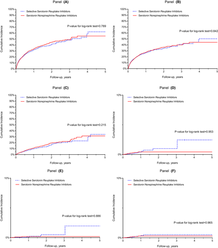

**FIGURE 2**

Open in figure viewer[PowerPoint](https://accpjournals.onlinelibrary.wiley.com/action/downloadFigures?id=phar2686-fig-0002&doi=10.1002%2Fphar.2686)

Unadjusted cumulative incidence rates among patients with stable hypertension and depression initiating serotonin norepinephrine reuptake inhibitors versus selective serotonin reuptake inhibitors (SSRIs). (A) Incidence of antihypertensive treatment intensification, (B) incidence of augmentation, (C) incidence of dose escalation, (D) incidence of major adverse cardiovascular events, (E) incidence of acute myocardial infarction (AMI), (F) incidence of stroke

### 3.3 Risk of MACE and individual components of MACE

For the primary as-treated analysis, the serotonin norepinephrine reuptake inhibitor group had 15 events of MACE over 3862 person-years of follow-up (incidence rate, 3.9 per 1000 person-years) compared with 17 events over 4274 person-years of follow-up in the SSRI group (incidence rate, 4.0 per 1000 person-years) (Table 2). Compared to SSRIs, initiation of serotonin norepinephrine reuptake inhibitors was associated with a similar risk of MACE (aHR: 0.98, [95% CI: 0.49, 1.96]). Findings were consistent for the risk of individual components of MACE. No differences in the risk of stroke (aHR: 1.02, [95% CI: 0.42, 2.49]) and AMI (aHR: 1.08, [95% CI: 0.37, 3.12]) were observed between the two exposure groups. Kaplan–Meier plots comparing the cumulative incidence of the MACE, stroke, and AMI among patients initiating serotonin norepinephrine reuptake inhibitor versus SSRIs were consistent with these findings (Figure 2, panels D–F).

### 3.4 Sensitivity and subgroup analysis

Study findings were consistent across sensitivity and subgroup analyses. Except for nortriptyline, the risk of antihypertensive treatment intensification and the MACE outcome did not differ for individual antidepressants. However, whether this observed increased risk of MACE among nortriptyline users is due to the small number of patients (*n* = 442) receiving nortriptyline or due to a true difference in the risk is uncertain. Additionally, for antihypertensive treatment intensification and the MACE outcome, neither changing the definition for stable hypertension, i.e., requiring stable antihypertensive treatment in the 90 days before the index date, nor conducting the analysis by ITT approach appreciably changed point estimates compared to the primary analysis (Figure 3). Findings were also similar using SIPTW rather than PS matching (Table S2). We found no evidence of effect modification for age and sex, i.e., all *p* <sub>interaction</sub> >0.05 (Figure 4).

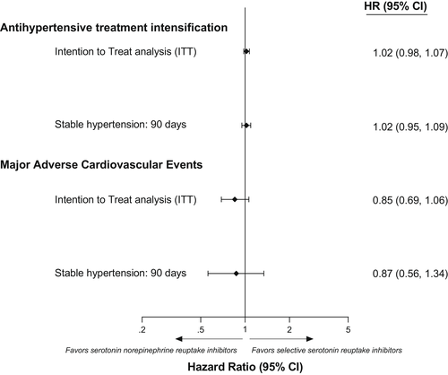

**FIGURE 3**

Open in figure viewer[PowerPoint](https://accpjournals.onlinelibrary.wiley.com/action/downloadFigures?id=phar2686-fig-0003&doi=10.1002%2Fphar.2686)

Results of sensitivity analysis comparing risk of major adverse cardiovascular events and antihypertensive treatment intensification among initiators of serotonin norepinephrine reuptake inhibitors versus selective serotonin reuptake inhibitors (SSRIs) (*N* = 19,160)

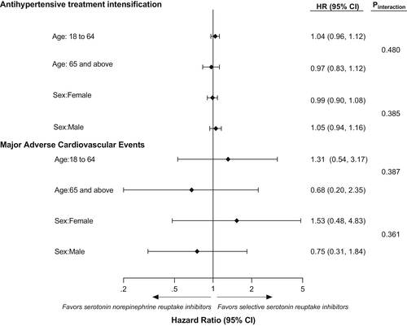

**FIGURE 4**

Open in figure viewer[PowerPoint](https://accpjournals.onlinelibrary.wiley.com/action/downloadFigures?id=phar2686-fig-0004&doi=10.1002%2Fphar.2686)

Results of subgroup analysis comparing risk of major adverse cardiovascular events and antihypertensive treatment intensification among initiators of serotonin norepinephrine reuptake inhibitors versus selective serotonin reuptake inhibitors (SSRIs) (*N* = 19,160)

## 4 DISCUSSION

Prior evidence for BP-interfering effects of serotonin norepinephrine reuptake inhibitors, such as venlafaxine and imipramine, originates from smaller observational and case studies.<sup>2, 5</sup> However, this association may have been based on poor quality evidence. Besides having limited generalizability and potential for recall bias, these studies were also limited by lack of contemporary control groups. Our study suggests that, to the extent norepinephrine reuptake inhibition has any causal effect on raising BP, it does not appear to translate into clinically meaningful loss of BP control, nor additional need for antihypertensive intensification. While we found no association between the use of serotonin norepinephrine reuptake inhibitors and risk of antihypertensive treatment intensification, a possible reason for this finding could be the use of low dose antidepressants in initial treatment of depression. Studies suggest that significant elevated BP due to use of serotonin norepinephrine reuptake inhibitors like venlafaxine occur primarily at high doses, i.e., >300 mg/day.<sup>2</sup> Presumably, this effect relates to venlafaxine preferentially inhibiting norepinephrine reuptake at these higher doses.<sup>25, 26</sup> A prior study in 3744 individuals with depression evaluated the blood pressure-interfering effects of venlafaxine and found that patients using venlafaxine had a dose-dependent effect on diastolic BP. Specifically, a dose higher than 300 mg/day had a 3-fold higher risk of elevated diastolic BP compared with those who took less than 300 mg/day.<sup>2</sup> Notably, in our study, most patients initiated venlafaxine with a total daily dose of less than 300 mg, which could explain the observed findings.

Findings of this study also extend previous findings by Almuwaqqat and colleagues that evaluated the association of antidepressants with cardiovascular events such as stroke and AMI, comparing SSRIs versus non-SSRIs antidepressants (i.e., TCAs and SNRIs) in older adults (45 to 64 years).<sup>27</sup> In the Atherosclerosis Risk in Communities (ARIC) study, the investigators concluded that the risk of stroke (HR: 1.07 [95% CI: 0.70, 1.63]) and AMI (HR: 0.91 [95% CI: 0.64, 1.29]) was similar for SSRIs and non-SSRIs. However, the ARIC analysis did not account for the potential confounding effects of depression, which itself is a strong risk factor for cardiovascular diseases. Nevertheless, the results of this study are in agreement with our results in finding no differences in the risk of MACE among initiators of serotonin norepinephrine reuptake inhibitors such as TCAs and SSRIs. Other studies have alluded to an increased risk of MACE with the use of serotonin norepinephrine reuptake inhibitors (i.e., TCA's and SSRI's). For example, our findings differ from an observational study conducted in patients with newly diagnosed depression which compared the risk of MACE between TCAs versus non-users of antidepressants.<sup>7</sup> That study found the use of TCAs to be associated with a modestly increased risk of MACE (HR: 1.20 [95% CI: 1.03, 1.40]).<sup>7</sup> Likewise, in another study of adults with obesity and depression, compared to non-use of antidepressants, use of TCAs (HR: 1.26 [95% CI: 1.01, 1.58]) was associated with increased risk of cardiovascular events.<sup>8</sup> We suspect a possible reason for the discrepancy in findings may be confounding by indication due to the absence of an active comparator in these prior studies.

Our study has several limitations. First, the claims data used for the study did not include information on BP measurements, and we could not ensure similar baseline BP prior to antidepressant initiation. Therefore, our study may suffer from residual confounding. However, we required patients to have stable hypertension before cohort entry with the assumption that lack of antihypertensive regimen adjustments would be indicative of BP control, or at least stable BP, and that any changes in the antihypertensive regimen after initiation of antidepressants would be because of the BP-interfering effects of antidepressants. Nevertheless, we cannot rule out the possibility that baseline BP differed between groups, particularly if prescribers avoided SNRIs in patients presumed to be at higher risk of losing BP control. Second, even though the primary outcome of MACE was defined using previously validated claims-based algorithms, the definition relied on ICD-9-CM and ICD-10-CM diagnosis codes and outcome misclassification cannot be ruled out. However, we expect misclassification of the outcome to be non-differential across the two exposure groups which would be expected to bias the results toward the null. Third, our findings may not be generalizable beyond populations defined by our inclusion criteria. Future studies in other populations may be needed. Fourth, we could not account for several predictive factors of cardiovascular risk that were not measurable in claims data such as OTC NSAID use, body mass index, alcohol use, and smoking. Despite these limitations, our study has notable strengths. First, we included a heterogenous population representative of the commercially insured population in the United States. Second, we used rigorous pharmacoepidemiologic approaches such as new-user design and active comparator study design, 1:1 propensity score matching for confounder adjustment, and validated outcome definitions for MACE.

## CONFLICT OF INTEREST

The authors declare no conflicts of interest.

## Citing Literature

[figure not shown]

[Volume42, Issue6](https://accpjournals.onlinelibrary.wiley.com/toc/18759114/2022/42/6)

June 2022

Pages 472-482

### Recommended

  [Pharmacotherapy: The Journal of Human Pharmacology and Drug Therapy](https://accpjournals.onlinelibrary.wiley.com/journal/18759114)

[Download PDF](https://accpjournals.onlinelibrary.wiley.com/doi/pdf/10.1002/phar.2686)

back